# EMA Preprocessing Report

Walter G. Dyer, wdyer@psu.edu, Penn State University

2026-04-02

# Overview and data collection procedure

This R Markdown file is based on Revol et al. (2024)’s step-by-step guidelines for preprocessing ESM data: https://preprocess.esmtools.com. It includes code adapted from Steps 1 - 4, tailored to preprocess EMA data for a secondary analysis of EMA data from the DVAL project (https://osf.io/nb9ct/overview?view_only=4f777b3907bb47aab6387aaa4353285c). In Part 2 of the study, participants received semi-random prompts 6 times throughout the day within predeterimined 2-hr intervals for 3 consecutive days, and were instructed to smoke at their normal rate. In Part 6 of the study, the same sampling scheme continued for 7 more days, during which participants were informed they could receive daily cash bonuses for day-level cigarette abstinence and were asked to biochemically verify abstinence daily. Both EMA datasets will be combined for this study’s analyses, and time-invariant variables (e.g., age, cigarette dependence) will be pulled from a baseline dataset. The steps to prepare the data for analysis are described below.

# Load packages

Import the packages:

```r
#Data management
library(dplyr)
library(tidyr)
library(data.table)
library(here)
library(readr)
library(readxl)
library(esmtools) # For button(), txt() functions

# Descriptive statistics
library(skimr)

# Missing values inspection
library(naniar)
library(visdat)

# Plotting
library(ggplot2)

# Character manipulation
library(stringr)
library(janitor)

# Dates and times
library(lubridate)
library(hms)
```

# Step 1: Import data and preliminary preprocessing

This section is dedicated to the first look at the data, the merging of data sources, the first basic preprocessing methods (e.g., duplicates, branching items check), and checking the variable consistency when the data have just been imported.

Import the data:

```r
# Define path to EMA Part 2 and Part 6 data
part2_path <- here("data", "DVAL_EMA_Part2_beeped.csv")
part6_path <- here("data", "DVAL_EMA_Part6_beeped.csv")
```

Inspection: Part 2 EMA raw dataset meta-info:

```r
dataInfo(file_path = part2_path,
         read_fun = read.csv,
         idvar = "participant_id",
         timevar = "init_time")
```

```
## Path : /Users/wkd5065/Library/CloudStorage/OneDrive-ThePennsylvaniaStateUniversity/Projects/ASH/DVAL/Users/Walter/Dissertation/Dissertation_Git/data/DVAL_EMA_Part2_beeped.csv
## Extension : csv
## Size : 2808.38 Kb
## Creation time : 2026-02-11 10:15:52.781662
## Update time : 2024-03-18 14:15:28
## ncol : 106
## nrow : 2077
## Number participants : 117
## Average number obs : 17.75214
## Period : from 2017-06-06 11:15:00 to 2021-12-03 19:40:02
## Variables : participant_id, session_id, study_day, survey_date, date_complete, date_submit, time_start, time_complete, time_submit, init_time, completion_time, submission_time, survey_status, esn, survey_name, survey_action, survey_type, lat, lng, timezone, happy_time, happy, dissatisfied_time, d…
```

Inspection: Part 6 EMA raw dataset meta-info:

```r
dataInfo(file_path = part6_path,
         read_fun = read.csv,
         idvar = "participant_id",
         timevar = "init_time")
```

```
## Path : /Users/wkd5065/Library/CloudStorage/OneDrive-ThePennsylvaniaStateUniversity/Projects/ASH/DVAL/Users/Walter/Dissertation/Dissertation_Git/data/DVAL_EMA_Part6_beeped.csv
## Extension : csv
## Size : 3300.95 Kb
## Creation time : 2026-02-10 14:09:34.056208
## Update time : 2024-03-18 14:16:53
## ncol : 106
## nrow : 2451
## Number participants : 59
## Average number obs : 41.54237
## Period : from 2017-08-09 11:08:00 to 2022-02-22 19:48:00
## Variables : participant_id, session_id, study_day, survey_date, date_complete, date_submit, time_start, time_complete, time_submit, init_time, completion_time, submission_time, survey_status, esn, survey_name, survey_action, survey_type, lat, lng, timezone, happy_time, happy, dissatisfied_time, d…
```

# Import data and prepare for preprocessing steps

The following code prepares the EMA data for Revol et. al.’s preprocessing steps. The data are be subset, how to define missing values is specified, variables are formatted to their respective types (e.g., numeric, character), and formatting issues related to cases where participants opted out of a survey are dealt with.

Modification 1: Data are subsetted to include only participants who completed Part 2 (Part 6 EMA is already subsetted to include only-completers of Part 6).

Modification 2: EMA variables relevant to the study are extracted, and missingness is standardized across variables.

Issue: Instances where participants opted out were reported by the literal text ‘opted out’ in the raw dataset, making the data incompatible with the command to format the variable as numeric.

Modification 3: In order to maintain these data but in a format compatible with numeric formatting, a variable to track opted out instances is created to check whether further actions to account for these cases must be taken, and cases with the text ‘opted out’ are replaced with ‘NA’.

Issue: The variable smoked_since_last_survey gave participants the option to select ‘6+’ which, while useful for other analyses, prevents us from formatting the variable as numeric.

Modification 4: The chunk below converts ‘6+’ to 6 for the variable smoked_since_last_survey.

Issue: Continuous variables must be formatted as numeric.

Modification 5: The chunk below formats continuous variables as numeric for later analyses.

Issue: Time variables must be reformatted.

Modification 6: The chunk below formats time variables as POSIXct for later analysis.

The EMA data are now prepared for Revol et. al.’s preprocessing workflow but must be merged with the parent study’s baseline dataset for time-invariant variables (e.g., covariates). The below code prepares the baseline data for merge.

Issue: Baseline data are raw. Some measures of time-invariant characteristics (e.g., Fagerstrom Test for Cigarette Dependence) need scoring and some variables require renaming/relabeling.

Modification 7: Baseline variables are preprocessed according to survey author guidelines (see parent study online repository for full list of baseline measures) and planned analyses.

Baseline data are now prepared for merging with the EMA data.

Issue: The EMA data alone do not contain all participant data needed for analyses. They must be combined with baseline data.

Modification 8: The EMA and Baseline Data are merged in the order: EMA variables, then Baseline variables.

Baseline and EMA data are now merged.

Issue: Daily biochemical abstinence verification (i.e., breath Carbon Monoxide (CO) concentration) data must be included for validity checks.

Modification 9: Biochemical abstinence verification data are read in, cleaned, and merged with the EMA+baseline dataset.

We now have a single dataset containing EMA, baseline, and CO video data, called study_sample.

Inspection: study_sample dataset meta-info:

```r
cat("## Path      : in-memory dataframe\n")
```

```
## ## Path      : in-memory dataframe
```

```r
cat("## Extension : RDS (original format, now in-memory)\n")
```

```
## ## Extension : RDS (original format, now in-memory)
```

```r
cat("## Size      :", format(object.size(study_sample), units = "auto"), "\n\n")
```

```
## ## Size      : 1.1 Mb
```

```r
# Dimensions
cat("## ncol      :", ncol(study_sample), "\n")
```

```
## ## ncol      : 36
```

```r
cat("## nrow      :", nrow(study_sample), "\n\n")
```

```
## ## nrow      : 4144
```

```r
# Number of participants
id_var <- "participant_id"
n_participants <- n_distinct(study_sample[[id_var]])
cat("## Number of participants :", n_participants, "\n")
```

```
## ## Number of participants : 95
```

```r
# Average number of observations per participant
avg_obs <- nrow(study_sample) / n_participants
cat("## Average number of observations per participant :", round(avg_obs, 1), "\n\n")
```

```
## ## Average number of observations per participant : 43.6
```

```r
# Time period
time_var <- "init_time"
if(time_var %in% names(study_sample)) {
  time_min <- min(study_sample[[time_var]], na.rm = TRUE)
  time_max <- max(study_sample[[time_var]], na.rm = TRUE)
  cat("## Period : from", format(time_min, "%Y-%m-%d %H:%M:%S"),
      "to", format(time_max, "%Y-%m-%d %H:%M:%S"), "\n\n")
} else {
  cat("## Period : init_time variable not found in dataset\n\n")
}
```

```
## ## Period : from 2017-06-06 11:15:00 to 2022-02-22 19:48:00
```

```r
# Variable names
cat("## Variables :", paste(names(study_sample), collapse = ", "), "\n")
```

```
## ## Variables : mood, smoke, before_survey, unpleasant, prior_mood, smoked_since_last_survey, pleasant, participant_id, session_id, completion_time, init_time, study_part, race, age, gender, total_household_income, bank_balance, employment_status, ftnd_sum, cigsperday, shaps_sim_sum, panas_pos, pa…
```

# Flag (in)valid observations

We use logical tests to define which observations are valid so that we can compare the total N of valid observations between the two datasets. The ‘valid’ observations are the ones where there are no missing values in the variables of interest (i.e., ‘mood’, ‘before_survey’, ‘smoke’), and two others that branch off of the variable ‘before_survey’ (‘pleasant’, ‘unpleasant’) . Below we create a validity function that can be used to filter data later.

```r
# Create validity function
check_validity <- function(df) {

  mood_ok          <- !is.na(df$mood)
  before_survey_ok <- !is.na(df$before_survey)
  smoke_ok         <- !is.na(df$smoke)

  # At least one of pleasant or unpleasant must be non-missing
  branch_ok <- !is.na(df$pleasant) | !is.na(df$unpleasant)

  is_valid <- mood_ok & before_survey_ok & smoke_ok & branch_ok

  as.integer(is_valid)
}
```

## First glimpse

Revol and colleagues’ (2024) step for renaming and relabeling step skipped here because it was completed in previous steps.

## Duplication

Issue: Participant #102 had two observations within a single observation 2-hr observation window due to a time-out issue. This issue arose when one of their surveys was interrupted and resent to the participant, but both the interrupted and the actual observation were saved. This interrupted observation contained no usable data.

Modification 10: The following code removes the interrupted observation from participant 102 and revisits obsno summary to ensure Participant #102’s max obsno == 60.

## Branching items

No issues detected.

# Check variable coherence

No issues detected.

## First missing values analysis

Here, our goal is to gain an overview of the patterns of missing values and address any preliminary issues related to them. The following plot gives an overview of the missing values in the dataframe.

## Overview of missing values

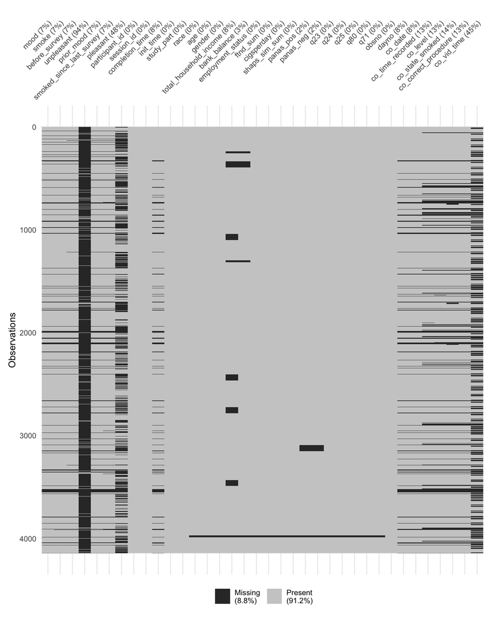

```r
data <- study_sample %>%
  arrange(participant_id, completion_time)

vis_miss(study_sample) +
  theme(
    plot.margin = margin(t = 10, r = 10, b = 10, l = 10),
    axis.text.x = element_text(angle = 45, hjust = 1)
  )
```

We can see multiple patterns and some missingness among the EMA variables.

We can get a sense for patterns of missingness by identifying the potential relationships or dependencies in missing values between variables (bottom) and the occurrences of each pattern (top).

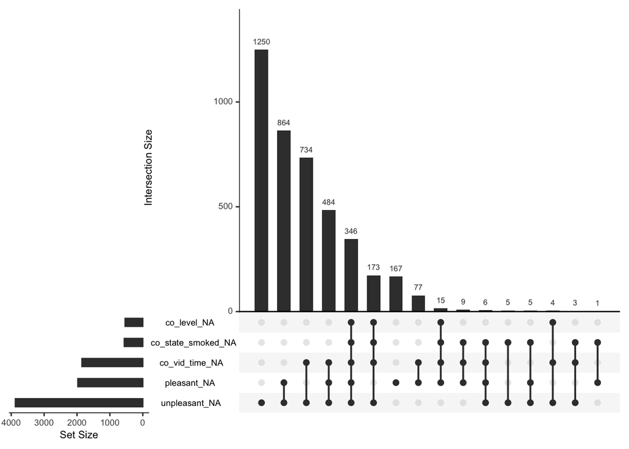

```r
gg_miss_upset(study_sample)
```

Skipped Revol & colleagues’ (2024) step to check coherence of missing values in the variables of interest because what would go here – the missingness pattern between ‘before_survey’, ‘pleasant’, and ‘unpleasant’ was already examined above.

# Create time variables

Flag (in)valid observations: Revol et. al. (2024)’s steps for validity checks were completed above. Skipped here.

# Step 2: Design and sample scheme checking

This section is dedicated to checking and solving issues due to inconsistencies between the planned and the actual design of the study.

## Sampling scheme plot and quantity of completed beeps

We proceed to the checking of the actual sample scheme and compare it to the defined one.

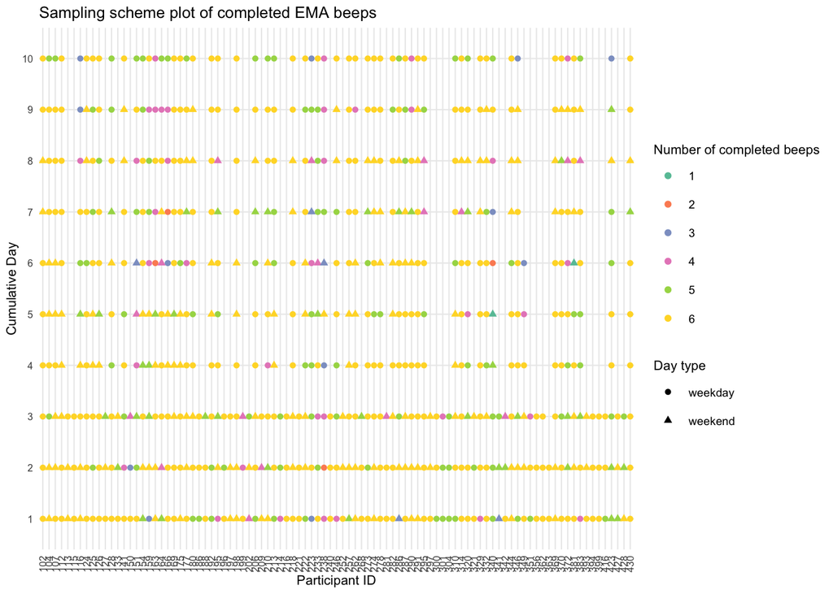

```r
study_sample %>%
  filter(!is.na(completion_time)) %>%
  mutate(
    weekday_type = ifelse(wday(completion_time, week_start = 1) %in% c(6,7), "weekend", "weekday")
  ) %>%
  group_by(participant_id, dayno, weekday_type) %>%
  summarise(n_beeps = n(), .groups = "drop") %>%
  ggplot(aes(x = factor(participant_id), y = factor(dayno))) +
  geom_point(aes(color = factor(n_beeps), shape = weekday_type), size = 1.5) +  # smaller points
  scale_color_brewer(palette = "Set2") +
  theme_minimal(base_size = 8) +  # smaller base text size
  theme(
    axis.text.x = element_text(angle = 90, vjust = 0.5, hjust = 1, size = 6),
    axis.text.y = element_text(size = 6),
    legend.text = element_text(size = 7),
    legend.title = element_text(size = 8)
  ) +
  labs(
    title = "Sampling scheme plot of completed EMA beeps",
    x = "Participant ID",
    y = "Cumulative Day",
    color = "Number of completed beeps",
    shape = "Day type"
  )
```

Here we can see that week(end) days are unevenly distributed across participants, that participants who skip a survey one day tend to skip a survey on another day, and that compliance is generally good across participants (note: participant #363 was included in this sample even though they have 0 observations for day 3/3 of their participation).

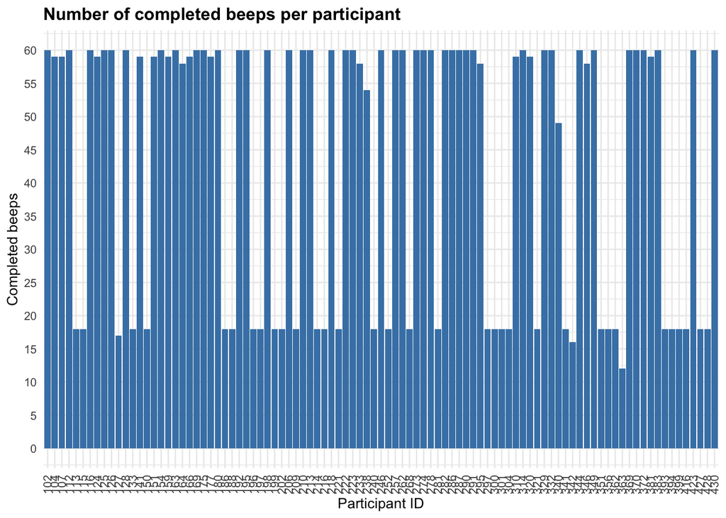

```r
# Examine number of completed beeps per participant
study_sample %>%
  group_by(participant_id) %>%
  summarize(n_completed_beeps = n(), .groups = "drop") %>%
  ggplot(aes(x = factor(participant_id), y = n_completed_beeps)) +
    geom_col(position = "dodge", fill = "steelblue") +
    scale_y_continuous(breaks = seq(0, max(study_sample$obsno, na.rm = TRUE), 5)) +
    labs(
      title = "Number of completed beeps per participant",
      x = "Participant ID",
      y = "Completed beeps"
    ) +
    theme_minimal(base_size = 10) +  # smaller base font size
    theme(
      axis.text.x = element_text(angle = 90, vjust = 0.5, hjust = 1),
      plot.title = element_text(face = "bold", size = 12)
    )
```

## Coherence timestamps

No issues detected.

Revol et. al.’s (2024) steps to examine time and delay to send steps were not possible with our dataset, given we lack a ‘sent’ variable. These steps were designed to determine whether the survey sending timing adhered to the sampling scheme, and the tests that are feasible in our dataset indicate the sampling scheme was adhered to.

# Step 3: Participants’ response behaviors

This section is dedicated to investigating how well participants engaged with the ESM study looking particularly for problematic patterns of behaviors (e.g., invalid observations, response time, careless responding).

## Sampling scheme, quantity of beeps and time started

No issues detected.

## Number of interactions

No issue detected.

## Interval 2 beeps

No issues detected.

## Compliance Rate

# Step 4: Compute and transform variables

This section is dedicated to computing and modifying variables of interest that will later be used in visualization and statistical analysis.

Modification 12: Person-level mean and person-mean-centered versions of variables that will be used in analyses.

```r
# Variables to process
vars <- c("mood", "smoke", "unpleasant", "prior_mood", "pleasant")

study_sample <- study_sample %>%
  group_by(participant_id) %>%  # compute within each person
  mutate(
    across(all_of(vars), ~ mean(.x, na.rm = TRUE), .names = "{.col}_pm"),  # person mean (between-person)
    across(all_of(vars), ~ .x - mean(.x, na.rm = TRUE), .names = "{.col}_pmc")  # person-mean centered (within-person)
  ) %>%
  ungroup()
```

Inspection: Preproessed dataset meta-info:

```r
cat("## Path      : in-memory dataframe\n")
```

```
## ## Path      : in-memory dataframe
```

```r
cat("## Extension : RDS (original format, now in-memory)\n")
```

```
## ## Extension : RDS (original format, now in-memory)
```

```r
cat("## Size      :", format(object.size(study_sample), units = "auto"), "\n\n")
```

```
## ## Size      : 1.7 Mb
```

```r
# Dimensions
cat("## ncol      :", ncol(study_sample), "\n")
```

```
## ## ncol      : 55
```

```r
cat("## nrow      :", nrow(study_sample), "\n\n")
```

```
## ## nrow      : 4143
```

```r
# Number of participants
id_var <- "participant_id"
n_participants <- n_distinct(study_sample[[id_var]])
cat("## Number of participants :", n_participants, "\n")
```

```
## ## Number of participants : 95
```

```r
# Average number of observations per participant
avg_obs <- nrow(study_sample) / n_participants
cat("## Average number of observations per participant :", round(avg_obs, 1), "\n\n")
```

```
## ## Average number of observations per participant : 43.6
```

```r
# Time period
time_var <- "init_time"
if(time_var %in% names(study_sample)) {
  time_min <- min(study_sample[[time_var]], na.rm = TRUE)
  time_max <- max(study_sample[[time_var]], na.rm = TRUE)
  cat("## Period : from", format(time_min, "%Y-%m-%d %H:%M:%S"),
      "to", format(time_max, "%Y-%m-%d %H:%M:%S"), "\n\n")
} else {
  cat("## Period : init_time variable not found in dataset\n\n")
}
```

```
## ## Period : from 2017-06-06 11:15:00 to 2022-02-22 19:48:00
```

```r
# Variable names
cat("## Variables :", paste(names(study_sample), collapse = ", "), "\n")
```

```
## ## Variables : mood, smoke, before_survey, unpleasant, prior_mood, smoked_since_last_survey, pleasant, participant_id, session_id, completion_time, init_time, study_part, race, age, gender, total_household_income, bank_balance, employment_status, ftnd_sum, cigsperday, shaps_sim_sum, panas_pos, pa…
```

```r
# Save the study_sample dataframe as an RDS file
saveRDS(study_sample, file = here("output", "cleaned_study_sample.RDS"))
```

# References

Revol, J., Carlier, C., Lafit, G., Verhees, M., Sels, L., & Ceulemans, E. (2024). Preprocessing ESM data: a step-by-step framework, tutorial website, R package, and reporting templates.